# IND320 – Compulsory work 2

Reservoir statistics from the NVE Magasinstatistikk API, cross-border electricity flows from ENTSO-E, stored in Cassandra with Spark and in MongoDB for the Streamlit app.

## Links

- GitHub repository: https://github.com/maryanahmed11011-pixel/IND320.prosjekt.maryan (branch `del2`)
- Streamlit app (part 2, branch `del2`): https://ind320-maryan-del2.streamlit.app/
- Streamlit app (part 1, branch `main`): https://ind320prosjektmaryan-lmvbjxajmrnrqkykq8ivne.streamlit.app/

## Bruk av KI

Jeg har brukt Claude (Anthropic) som assistent gjennom hele denne delen. Den veiledet meg steg for steg gjennom installasjonen av WSL, Docker, Cassandra, Java, Hadoop/winutils og PySpark, og hjalp meg med å feilsøke problemer (feil JAVA_HOME, tidsavbrudd i Cassandra og en ugyldig API-token). Den foreslo også kode for API-kallene, Spark–Cassandra- og MongoDB-cellene, og laget utkast til de fleste av de oppdaterte Streamlit-sidene, som jeg deretter testet, justerte og sjekket mot oppgaveteksten. All kode er kjørt og kontrollert av meg.

## Logg

Jeg startet del 2 med å følge tilbakemeldingen fra del 1: Jeg lagde en ny branch (`del2`), flyttet notebookene til en egen `notebooks`-mappe og fjernet `__pycache__` fra repoet.

Mesteparten av tiden gikk med til å sette opp den lokale databasen på Windows. Jeg installerte WSL og Docker Desktop, og kjørte Cassandra i en Docker-container. Til Spark installerte jeg først Java 25 ved en feil, og måtte bytte til Java 17, som er den høyeste versjonen som anbefales for Spark på Windows. Deretter hang Spark uten noen nyttig feilmelding. Årsaken var at JAVA_HOME pekte på en mappe som ikke fantes, noe jeg fant ut ved å sjekke stien med `Test-Path`. Jeg lærte også at `getOrCreate()` gjenbruker en Spark-økt som allerede kjører, så Cassandra-koblingen må settes opp første gang Spark startes.

Til MongoDB lagde jeg et gratis cluster i Atlas og lagret tilkoblingsstrengen i `.streamlit/secrets.toml`, som holdes utenfor GitHub med `.gitignore`.

CSV-filen for magasinstatistikken ble erstattet med en direkte tilkobling til NVEs API. API-et dekker hele Norge (NO, område 0), prisområdene NO1–NO5 (EL) og fire vassdragsområder (VASS). Ved å gi API-kolonnene de samme engelske navnene som i del 1, kunne jeg gjenbruke plottekoden uendret. Som i del 1 måtte datokolonnen gjøres om til datetime.

Fra ENTSO-E hentet jeg fysisk kraftflyt over landegrensene for 2024–2025, for alle ni norske forbindelser i begge retninger. Nedlastingen tok rundt 45 minutter, så jeg lagret en lokal backup for å slippe å gjenta den. En 401-feil viste seg å skyldes et mellomrom etter tokenen. Skrivingen av de 315 792 timesradene til Cassandra med Spark feilet flere ganger med tidsavbrudd, fordi den ene Cassandra-noden i Docker ikke klarte å holde tritt. Dette løste jeg ved å begrense skrivehastigheten, og ved lesing mellomlagret jeg dataene i Spark slik at Cassandra bare ble spurt én gang. Spark ble så brukt til kakediagrammet, linjeplottet for januar og til å summere dataene til daglige verdier, som ble lagt inn i MongoDB.

I Streamlit-appen hentes magasindataene nå fra API-et, med caching. Radioknapper velger områdetype (NO, EL, VASS), og plottene og LineChartColumn viser én linje per område. Glidebryteren velger hvilken periode som lastes inn. En ny side viser kraftflyten fra MongoDB i to kolonner, med et kakediagram, et linjeplott for valgfrie måneder valgt med pills, og en expander som beskriver datakilden. Plassholdersiden ble flyttet til side fem.

Den viktigste lærdommen fra denne delen var at oppsett og feilsøking tok mye mer tid enn å skrive selve analysekoden, og at linjen «Caused by» i lange feilmeldinger som regel er nøkkelen til å finne det egentlige problemet.

## Setup: Cassandra and Spark

Cassandra runs locally in Docker (`my_cassandra`). Spark uses Java 17, Hadoop/winutils and the Spark-Cassandra connector 3.5.1. The cells below set up the environment and test the connection.

```python
import os, sys

# Point Spark to Java 17, Hadoop/winutils and the Python in this environment
os.environ["JAVA_HOME"] = r"C:\Program Files\Microsoft\jdk-17.0.20.101-hotspot"
os.environ["HADOOP_HOME"] = "C:/Hadoop/hadoop-3.3.1"
os.environ["PATH"] += ";C:/Hadoop/hadoop-3.3.1/bin"
os.environ["PYSPARK_HADOOP_VERSION"] = "without"
os.environ["PYSPARK_PYTHON"] = sys.executable
os.environ["PYSPARK_DRIVER_PYTHON"] = sys.executable
```

```python
from cassandra.cluster import Cluster
cluster = Cluster(["127.0.0.1"], port=9042)
# Connect to Cassandra running in Docker

session = cluster.connect()

# Create a keyspace and a small test table
session.execute("""
    CREATE KEYSPACE IF NOT EXISTS test_keyspace
    WITH replication = {'class': 'SimpleStrategy', 'replication_factor': 1};
""")
session.execute("""
    CREATE TABLE IF NOT EXISTS test_keyspace.test_table (id int PRIMARY KEY, name text);
""")
print("Cassandra OK")
```

```
Cassandra OK
```

```python
from pyspark.sql import SparkSession

# Start Spark with the Spark-Cassandra connector (downloaded automatically the first time)
spark = (SparkSession.builder
         .appName("CassandraTest")
         .config("spark.jars.packages", "com.datastax.spark:spark-cassandra-connector_2.12:3.5.1")
         .config("spark.cassandra.connection.host", "127.0.0.1")
         .config("spark.cassandra.connection.port", "9042")
         .config("spark.sql.session.timeZone", "UTC")
         .getOrCreate())
print("Spark OK")
```

```
Spark OK
```

```python
# Write two rows to Cassandra via Spark
df = spark.createDataFrame([(1, "Maryan"), (2, "Test")], ["id", "name"])
(df.write.format("org.apache.spark.sql.cassandra")
   .options(table="test_table", keyspace="test_keyspace")
   .mode("append").save())

# Read them back
(spark.read.format("org.apache.spark.sql.cassandra")
   .options(table="test_table", keyspace="test_keyspace")
   .load().show())
```

```
+---+------+
| id|  name|
+---+------+
|  2|  Test|
|  1|Maryan|
+---+------+
```

## Setup: MongoDB

MongoDB Atlas (free cluster). The connection string is read from `.streamlit/secrets.toml`, which is excluded from GitHub.

```python
import toml
from pymongo import MongoClient

# Read the connection string from secrets.toml (kept out of GitHub)
secrets = toml.load("../.streamlit/secrets.toml")
client = MongoClient(secrets["mongo"]["uri"])

# Insert and read back a test document
db = client["ind320"]
db["test"].insert_one({"navn": "test", "verdi": 1})
print(db["test"].find_one({"navn": "test"}))
```

```
{'_id': ObjectId('6ad6184ac580b871c2251e42'), 'navn': 'test', 'verdi': 1}
```

## Magasinstatistikk from the NVE API

Reservoir data are now fetched directly from NVE's open Magasinstatistikk API instead of the CSV file from part 1.

The API covers three area types: the whole of Norway (NO, area 0), the five price areas NO1–NO5 (EL, areas 1–5) and four river system regions (VASS, areas 1–4). Data are weekly, with filling level and capacity for each area. As in part 1, the date column (dato_Id) is converted to datetime, and the rows are sorted by date to make sure the time series is in chronological order.

```python
import requests
import pandas as pd

# Base URL for NVE's Magasinstatistikk API (no API key needed)
BASE_URL = "https://biapi.nve.no/magasinstatistikk/api/Magasinstatistikk"

# Fetch all public reservoir statistics
response = requests.get(f"{BASE_URL}/HentOffentligData", timeout=30)
response.raise_for_status()
df_mag = pd.DataFrame(response.json())

# Convert the date column to proper datetime
df_mag["dato_Id"] = pd.to_datetime(df_mag["dato_Id"])

df_mag.head()
```

|  | dato_Id | omrType | omrnr | iso_aar | iso_uke | fyllingsgrad | kapasitet_TWh | fylling_TWh | neste_Publiseringsdato | fyllingsgrad_forrige_uke | endring_fyllingsgrad |
| --- | --- | --- | --- | --- | --- | --- | --- | --- | --- | --- | --- |
| 0 | 1995-09-03 | EL | 4 | 1995 | 35 | 0.944721 | 21.079208 | 19.913979 | 0001-01-01T00:00:00 | 0.936888 | 0.007833 |
| 1 | 2020-11-15 | EL | 1 | 2020 | 46 | 0.974361 | 6.003264 | 5.849344 | 2020-11-25T13:00:00 | 0.997406 | -0.023046 |
| 2 | 2011-08-28 | EL | 4 | 2011 | 34 | 0.786499 | 21.079208 | 16.578772 | 0001-01-01T00:00:00 | 0.787193 | -0.000694 |
| 3 | 1998-07-05 | EL | 3 | 1998 | 27 | 0.793969 | 8.920932 | 7.082947 | 0001-01-01T00:00:00 | 0.733812 | 0.060157 |
| 4 | 2011-03-27 | EL | 4 | 2011 | 12 | 0.300820 | 21.079208 | 6.341054 | 0001-01-01T00:00:00 | 0.311122 | -0.010301 |

```python
# Fetch the list of areas covered by the API
response = requests.get(f"{BASE_URL}/HentOmråder", timeout=30)
response.raise_for_status()
areas = response.json()

# The API returns a list - handle both possible structures
if isinstance(areas, list) and len(areas) > 0 and "omrnr" not in areas[0]:
    # A list containing one dict with keys like land/elspot/vassdrag
    areas = areas[0]
    for area_type, area_list in areas.items():
        print(area_type, [a["omrnr"] for a in area_list])
else:
    # A flat list of areas - group them by area type
    df_areas = pd.DataFrame(areas)
    print(df_areas.groupby("omrType")["omrnr"].apply(list))

# Area types present in the reservoir data
print(df_mag["omrType"].unique())
```

```
land [0]
elspot [1, 2, 3, 4, 5]
vassdrag [1, 2, 3, 4]
['EL' 'NO' 'VASS']
```

```python
# Show full names and descriptions for all areas
rows = []
for area_type, area_list in areas.items():
    for a in area_list:
            rows.append({"type": area_type, "nr": a["omrnr"],
                     "navn": a["navn"], "beskrivelse": a["beskrivelse"]})
pd.DataFrame(rows)
```

|  | type | nr | navn | beskrivelse |
| --- | --- | --- | --- | --- |
| 0 | land | 0 | Norge | Hele landet |
| 1 | elspot | 1 | NO 1 | Sørøst-Norge. Omfatter østlige del av Østlande... |
| 2 | elspot | 2 | NO 2 | Sørvest-Norge. Omfatter mesteparten av Vestfol... |
| 3 | elspot | 3 | NO 3 | Midt-Norge. Omfatter nordre og vestlige del av... |
| 4 | elspot | 4 | NO 4 | Nord-Norge. Omfatter resten av Trøndelag og No... |
| 5 | elspot | 5 | NO 5 | Vest-Norge. Omfatter midtre del av Vestland op... |
| 6 | vassdrag | 1 | VASS1 | Sørøst-Norge. Østlandet, Agder og deler av Rog... |
| 7 | vassdrag | 2 | VASS2 | Vest-Norge. Resten av Rogaland og Vestland. |
| 8 | vassdrag | 3 | VASS3 | Midt-Norge. Møre og Romsdal, Trøndelag og sørl... |
| 9 | vassdrag | 4 | VASS4 | Nord-Norge. Resten av Nordland og nordover. |

```python
import matplotlib.pyplot as plt
from IPython.display import display

# Same English column names as in part 1, so the plotting code can be reused
rename_map = {
    "dato_Id": "date",
    "omrType": "area_type",
    "omrnr": "area_number",
    "iso_aar": "iso_year",
    "iso_uke": "iso_week",
    "fyllingsgrad": "filling_degree",
    "kapasitet_TWh": "capacity_TWh",
    "fylling_TWh": "filling_TWh",
    "neste_Publiseringsdato": "next_publication_date",
    "fyllingsgrad_forrige_uke": "filling_degree_prev_week",
    "endring_fyllingsgrad": "filling_degree_change",
}
df = df_mag.rename(columns=rename_map)
df["date"] = pd.to_datetime(df["date"])

# National total for Norway, sorted by date (same as in part 1)
norway = df[df["area_type"] == "NO"].sort_values("date").reset_index(drop=True)
measure_cols = norway.select_dtypes("number").columns.tolist()

print("Date range:", norway["date"].min().date(), "to", norway["date"].max().date())
display(norway.head())
```

```
Date range: 1995-01-08 to 2026-10-11
```

|  | date | area_type | area_number | iso_year | iso_week | filling_degree | capacity_TWh | filling_TWh | next_publication_date | filling_degree_prev_week | filling_degree_change |
| --- | --- | --- | --- | --- | --- | --- | --- | --- | --- | --- | --- |
| 0 | 1995-01-08 | NO | 0 | 1995 | 1 | 0.607988 | 87.43758 | 53.161003 | 0001-01-01T00:00:00 | 0.752631 | -0.144643 |
| 1 | 1995-01-15 | NO | 0 | 1995 | 2 | 0.582088 | 87.43758 | 50.896374 | 0001-01-01T00:00:00 | 0.607988 | -0.025900 |
| 2 | 1995-01-22 | NO | 0 | 1995 | 3 | 0.562121 | 87.43758 | 49.150486 | 0001-01-01T00:00:00 | 0.582088 | -0.019967 |
| 3 | 1995-01-29 | NO | 0 | 1995 | 4 | 0.534222 | 87.43758 | 46.711033 | 0001-01-01T00:00:00 | 0.562121 | -0.027899 |
| 4 | 1995-02-05 | NO | 0 | 1995 | 5 | 0.506221 | 87.43758 | 44.262720 | 0001-01-01T00:00:00 | 0.534222 | -0.028001 |

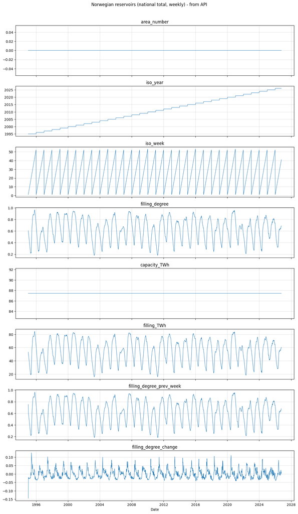

```python
# One subplot per measurement, with a shared time axis
fig, axes = plt.subplots(len(measure_cols), 1, figsize=(12, 2.6 * len(measure_cols)), sharex=True)

for ax, col in zip(axes, measure_cols):
    ax.plot(norway["date"], norway[col], linewidth=0.8)
    ax.set_title(col)
    ax.grid(True, alpha=0.4)

axes[-1].set_xlabel("Date")
fig.suptitle("Norwegian reservoirs (national total, weekly) - from API")
plt.tight_layout(rect=(0, 0, 1, 0.97))
plt.show()
```

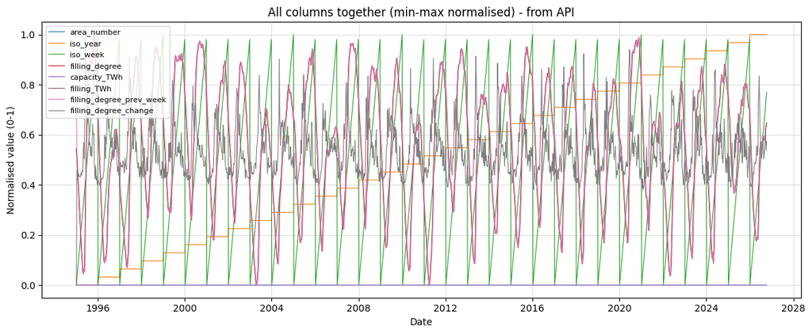

```python
# Min-max normalisation: (value - min) / (max - min) gives 0-1 for each column
values = norway[measure_cols]
spread = (values.max() - values.min()).replace(0, 1)  # avoid division by zero
normalised = (values - values.min()) / spread

fig, ax = plt.subplots(figsize=(12, 5))
for col in measure_cols:
    ax.plot(norway["date"], normalised[col], linewidth=0.8, label=col)

ax.set_title("All columns together (min-max normalised) - from API")
ax.set_xlabel("Date")
ax.set_ylabel("Normalised value (0-1)")
ax.legend(loc="upper left", fontsize=8)
ax.grid(True, alpha=0.4)
plt.tight_layout()
plt.show()
```

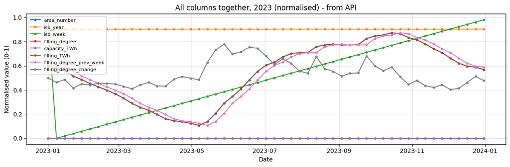

```python
# Same data for one year only, where the seasonal variation is easier to see
one_year = norway[norway["date"].dt.year == 2023]
norm_year = (one_year[measure_cols] - values.min()) / spread

fig, ax = plt.subplots(figsize=(12, 4))
for col in measure_cols:
    ax.plot(one_year["date"], norm_year[col], marker="o", markersize=3, label=col)
ax.set_title("All columns together, 2023 (normalised) - from API")
ax.set_xlabel("Date")
ax.set_ylabel("Normalised value (0-1)")
ax.legend(loc="upper left", fontsize=8)
ax.grid(True, alpha=0.4)
plt.tight_layout()
plt.show()
```

## Cross-border flows from ENTSO-E

Physical cross-border flows between the Norwegian price areas and neighbouring countries, retrieved with the `entsoe-py` library. The first cell tests the API for one week.

```python
import toml
import pandas as pd
from entsoe import EntsoePandasClient

# Read the ENTSO-E token from secrets.toml (kept out of GitHub)
secrets = toml.load("../.streamlit/secrets.toml")
client = EntsoePandasClient(api_key=secrets["entsoe"]["token"].strip())

# Test: physical flow from NO2 to Denmark (DK1) for one week
start = pd.Timestamp("2025-01-01", tz="Europe/Oslo")
end = pd.Timestamp("2025-01-08", tz="Europe/Oslo")
flow = client.query_crossborder_flows("NO_2", "DK_1", start=start, end=end)

flow.head(10)
```

```
2025-01-01 00:00:00+01:00    0.0
2025-01-01 01:00:00+01:00    0.0
2025-01-01 02:00:00+01:00    0.0
2025-01-01 03:00:00+01:00    0.0
2025-01-01 04:00:00+01:00    0.0
2025-01-01 05:00:00+01:00    0.0
2025-01-01 06:00:00+01:00    0.0
2025-01-01 07:00:00+01:00    0.0
2025-01-01 08:00:00+01:00    0.0
2025-01-01 09:00:00+01:00    0.0
Freq: 60min, dtype: float64
```

### Download two years for all connections (2024–2025)

```python
# All cross-border connections between Norwegian price areas and neighbouring countries
connections = [
    ("NO_1", "SE_3"),
    ("NO_2", "DK_1"),
    ("NO_2", "NL"),
    ("NO_2", "DE_LU"),
    ("NO_2", "GB"),
    ("NO_3", "SE_2"),
    ("NO_4", "SE_1"),
    ("NO_4", "SE_2"),
    ("NO_4", "FI"),
]

# The last two full years
start = pd.Timestamp("2024-01-01", tz="Europe/Oslo")
end = pd.Timestamp("2026-01-01", tz="Europe/Oslo")

frames = []
for no_area, foreign in connections:
    # Fetch both directions: out of Norway (export) and into Norway (import)
    for area_from, area_to, direction in [(no_area, foreign, "export"),
                                          (foreign, no_area, "import")]:
        try:
            s = client.query_crossborder_flows(area_from, area_to, start=start, end=end)
            # Some periods have 15-minute resolution - average to hourly values
            s = s.resample("h").mean()
            part = s.rename("flow_mw").reset_index().rename(columns={"index": "time"})
            part["time"] = part["time"].dt.tz_convert("UTC")  # store all times in UTC
            part["connection"] = f"{no_area}-{foreign}"
            part["from_area"] = area_from
            part["to_area"] = area_to
            part["direction"] = direction
            frames.append(part)
            print(f"OK: {area_from} -> {area_to} ({len(part)} rows)")
        except Exception as e:
            print(f"Failed: {area_from} -> {area_to}: {e}")

flows = pd.concat(frames, ignore_index=True)
flows.head()
```

This download takes about 45 minutes, so it was run once and the result saved to flows_backup.pkl. The cells below load the data from this backup.

```python
# Save a local backup so the slow API download doesn't have to be repeated
flows.to_pickle("flows_backup.pkl")

# To load it again later (instead of re-downloading):
# flows = pd.read_pickle("flows_backup.pkl")
```

### Insert the data into Cassandra using Spark

```python
# Keyspace and table for the cross-border flows.
# Partition key (connection, direction) groups each line and direction together,
# and time sorts the hourly values within each group.
session.execute("""
    CREATE KEYSPACE IF NOT EXISTS ind320
    WITH replication = {'class': 'SimpleStrategy', 'replication_factor': 1};
""")
session.execute("""
    CREATE TABLE IF NOT EXISTS ind320.flows (
        connection text,
        direction text,
        time timestamp,
        from_area text,
        to_area text,
        flow_mw double,
        PRIMARY KEY ((connection, direction), time)
    );
""")
print("Table ready")
```

```
Table ready
```

```python
# Load the ENTSO-E data from the local backup (the API download takes ~45 minutes)
import pandas as pd
flows = pd.read_pickle("flows_backup.pkl")
print("Rows loaded from backup:", len(flows))
```

```
Rows loaded from backup: 315792
```

```python
# Spark needs times without timezone info - they are already in UTC
flows_out = flows.copy()
flows_out["time"] = flows_out["time"].dt.tz_localize(None)
flows_out = flows_out.dropna(subset=["flow_mw"])

# Throttle the writes so the local single-node Cassandra in Docker keeps up
spark.conf.unset("spark.cassandra.output.batch.size.rows")
spark.conf.set("spark.cassandra.output.concurrent.writes", "1")
spark.conf.set("spark.cassandra.output.throughputMBPerSec", "1")

# One partition = one writer at a time
sdf = spark.createDataFrame(flows_out).repartition(1)
(sdf.write.format("org.apache.spark.sql.cassandra")
    .options(table="flows", keyspace="ind320")
    .mode("append").save())
print("Rows written:", sdf.count())
```

```
Rows written: 315792
```

### Extract relevant columns from Cassandra with Spark

```python
from pyspark.sql import functions as F

# Read gently from the local single-node Cassandra
spark.conf.set("spark.cassandra.concurrent.reads", "1")
spark.conf.set("spark.cassandra.input.fetch.sizeInRows", "500")

# Read the flows from Cassandra once, keep only the columns we need,
# and cache them in Spark so the plots below don't query Cassandra again
flows_spark = (spark.read.format("org.apache.spark.sql.cassandra")
               .options(table="flows", keyspace="ind320")
               .load()
               .select("connection", "direction", "time", "flow_mw")
               .cache())

print("Rows read from Cassandra:", flows_spark.count())
flows_spark.show(5)
```

```
Rows read from Cassandra: 315756
+----------+---------+-------------------+-------+
|connection|direction|               time|flow_mw|
+----------+---------+-------------------+-------+
|   NO_2-NL|   export|2023-12-31 22:00:00|    0.0|
|   NO_2-NL|   export|2023-12-31 23:00:00|    0.0|
|   NO_2-NL|   export|2024-01-01 00:00:00|    0.0|
|   NO_2-NL|   export|2024-01-01 01:00:00|    0.0|
|   NO_2-NL|   export|2024-01-01 02:00:00|    0.0|
+----------+---------+-------------------+-------+
only showing top 5 rows
```

315,756 rows were read back, 36 fewer than the 315,792 written. This is two rows per connection and direction, most likely duplicate timestamps around the daylight saving time changes, which Cassandra merges because `time` is part of the primary key.

### Pie chart: export vs import for one connection and year

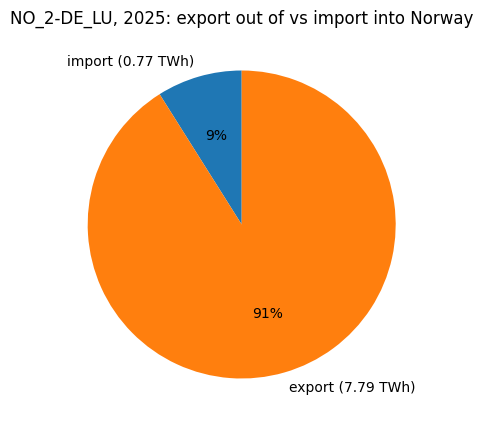

```python
# Choose connection and year
import matplotlib.pyplot as plt
conn = "NO_2-DE_LU"
year = 2025

# Spark sums the hourly MW values per direction (MW over one hour = MWh) -> TWh
pie_df = (flows_spark
          .filter((F.col("connection") == conn) & (F.year("time") == year))
          .groupBy("direction")
          .agg((F.sum("flow_mw") / 1e6).alias("TWh"))
          .toPandas())

fig, ax = plt.subplots(figsize=(5, 5))
ax.pie(pie_df["TWh"], labels=[f"{d} ({v:.2f} TWh)" for d, v in zip(pie_df["direction"], pie_df["TWh"])],
       autopct="%1.0f%%", startangle=90)
ax.set_title(f"{conn}, {year}: export out of vs import into Norway")
plt.show()
```

In 2025, about 91 % of the energy on the NO2–Germany connection (NordLink) flowed out of Norway.

### Line plot: January, one line per connection and direction

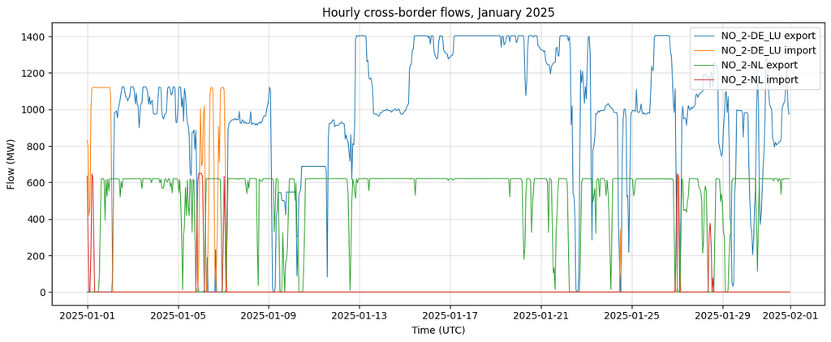

```python
# Choose year and which connections to show
year = 2025
chosen = ["NO_2-DE_LU", "NO_2-NL"]

# Filter with Spark: chosen connections, January of the chosen year
jan = (flows_spark
       .filter(F.col("connection").isin(chosen) &
               (F.year("time") == year) & (F.month("time") == 1))
       .toPandas()
       .sort_values("time"))

# One line per connection and direction
fig, ax = plt.subplots(figsize=(12, 5))
for (c, d), group in jan.groupby(["connection", "direction"]):
    ax.plot(group["time"], group["flow_mw"], linewidth=0.8, label=f"{c} {d}")

ax.set_title(f"Hourly cross-border flows, January {year}")
ax.set_xlabel("Time (UTC)")
ax.set_ylabel("Flow (MW)")
ax.legend()
ax.grid(True, alpha=0.4)
plt.tight_layout()
plt.show()
```

### Insert the Spark-extracted data into MongoDB

The hourly data are aggregated to daily energy per connection and direction with Spark, which gives a small, curated dataset for the Streamlit app.

```python
import toml
import pandas as pd
from pymongo import MongoClient

# Aggregate the hourly flows to daily energy (MWh) with Spark,
# so the Streamlit app gets a small, fast dataset
daily = (flows_spark
         .groupBy("connection", "direction", F.to_date("time").alias("date"))
         .agg(F.sum("flow_mw").alias("energy_mwh"))
         .toPandas())

# MongoDB needs full datetimes; year and month make filtering in Streamlit easy
daily["date"] = pd.to_datetime(daily["date"])
daily["year"] = daily["date"].dt.year
daily["month"] = daily["date"].dt.month

# Connect to MongoDB Atlas and replace any old data in the collection
secrets = toml.load("../.streamlit/secrets.toml")
client = MongoClient(secrets["mongo"]["uri"])
collection = client["ind320"]["flows_daily"]
collection.delete_many({})
collection.insert_many(daily.to_dict("records"))

print("Documents in MongoDB:", collection.count_documents({}))
```

```
Documents in MongoDB: 13176
```